# R Notebook Quantilille 2023

Module multiniveaux - Aspects géographiques - La croissance démographique des communes françaises

Clémentine Cottineau & Julie Vallée

30-06-2023

# Mise en place

## Charger des packages

```r
library(lme4) # pour la modélisation multiniveau
library(lmerTest) # pour l'évaluation des modèles
library(sf) # pour les objets spatiaux (cartes)
library(tidyverse) # pour la manipulation des données
library(readxl) # pour ouvrir les fichiers xlsx
library(languageR)
library (dplyr)
```

## Charger les données issues de la fiche Insee

Fiche INSEE : https://www.insee.fr/fr/statistiques/4267787

### Télecharger les données et les mettre dans un dossier “Data”

URL des données de la fiche INSEE : https://www.insee.fr/fr/statistiques/fichier/4267787/if177.xlsx

Note : grille communale de densité (1: commune densément peuplée ; 2: commune de densité intermédiaire ; 3: commune peu dense ; 4: commune très peu dense)

```r
  pop_com_raw <- read_excel("Data/if177.xlsx",
                         sheet = "Figure complémentaire 1", col_names = FALSE,
                         skip = 3)

  colnames(pop_com_raw) <- c("REG", "DEP", "CODGEO", "Commune", "DensiteChar", "P17_POP", "txvar", "VAR1", "VAR2", "VAR3")


  pop_comm <- pop_com_raw %>%
    filter(!is.na(CODGEO) | !is.na(txvar)) %>%
    mutate(densite = as.factor(substr(DensiteChar, start =1 , stop =1))) %>%
    select (REG, DEP, CODGEO, Commune, densite, P17_POP, txvar)
```

### Explorer la variable txvar (taux de variation annuelle de la population des communes entre 2007-2017)

Observer la distribution de la variable txvar

```r
 summary(pop_comm$txvar)
```

```
##    Min. 1st Qu.  Median    Mean 3rd Qu.    Max.    NA's
## -8.5000 -0.3000  0.4000  0.4851  1.2000 12.0000       6
```

Supprimer les communes avec txvar = NA

```r
 pop_comm <- pop_comm %>% drop_na(txvar)
```

Faire un histogramme par commune

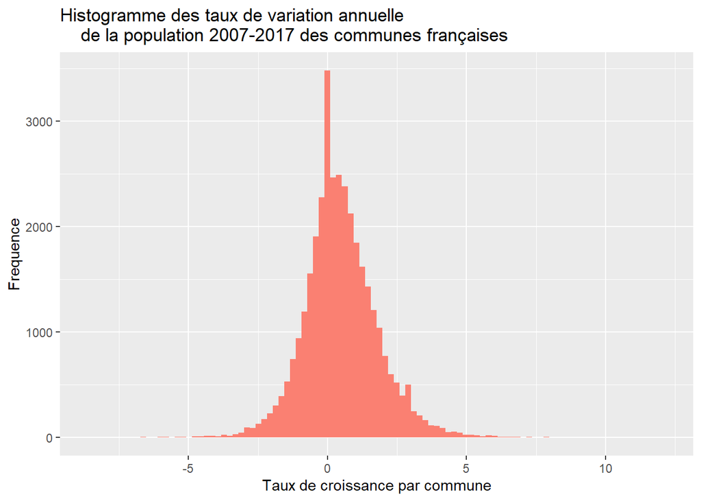

```r
  ggplot(pop_comm) +
    geom_histogram(aes(x = txvar), bins = 100, fill = "salmon") +
    labs(title = "Histogramme des taux de variation annuelle
    de la population 2007-2017 des communes françaises",
        x = "Taux de croissance par commune",
        y = "Frequence")
```

Valider les chiffres population totale en 2017 /note Insee (66 524 339)

```r
  sum (pop_comm$P17_POP)
```

```
## [1] 66524339
```

### Enrichir les données

Créer la variable “Population 2007 par commune” - à partir de tx var et POP 2017

Quelle formule ?

txvar <- ((pop2017 / pop2007)^(1/n) - 1)*100 (avec n=10 car 10 ans entre les deux valeurs) txvar <- (pop2017 / pop2007)^0.1 - 1)*100) => tvar/100 +1 = pop2017/pop2007)^0.1 => (tvar/100 + 1)^10 =pop2017/pop2007 => pop2007 = pop2017 / (tvar/100 + 1 )^10

```r
  pop_comm$P07_POP <-pop_comm$P17_POP / (((pop_comm$txvar/100) + 1)^10)
  pop_comm$P07_POP <- round(pop_comm$P07_POP, digits =0)
```

Note : On pourrait aussi vérifier avec les données de population 2007 importées d’une autre source URL : https://www.insee.fr/fr/statistiques/fichier/4515565/base-ccx-evol-struct-pop-2017.zip pop_comm_2007 <- read_excel(“base-cc-evol-struct-pop-2017.xlsx”, sheet = “COM_2007”, skip = 5) pop_comm_2007 <- pop_comm_2007 %>% select (CODGEO, REG, DEP, LIBGEO, P07_POP) pop_comm_2007$P07_POP <- round(pop_comm_2007$P07_POP, digits =0)

## Charger les données géographiques des départements

URL : https://geoservices.ign.fr/adminexpress

Choisir dossier “ADMIN-EXPRESS-COG-CARTO” édition 2021 par territoire France Métropolitaine

URL = https://wxs.ign.fr/x02uy2aiwjo9bm8ce5plwqmr/telechargement/prepackage/ADMINEXPRESS-COG-CARTO_SHP_TERRITOIRES_PACK_2021-05-19$ADMIN-EXPRESS-COG-CARTO_3-0__SHP_LAMB93_FXX_2021-05-19/file/ADMIN-EXPRESS-COG-CARTO_3-0__SHP_LAMB93_FXX_2021-05-19.7z>

Dézipper le dossier

Importer la couche des départements dans R

```r
  dep_fr <- st_read('Data/ADMIN-EXPRESS-COG-CARTO_3-0__SHP_LAMB93_FXX_2021-05-19/ADMIN-EXPRESS-COG-CARTO/1_DONNEES_LIVRAISON_2021-05-19/ADECOGC_3-0_SHP_LAMB93_FXX/DEPARTEMENT.shp',
                      quiet = TRUE)
```

Faire une carte “vide” des départements

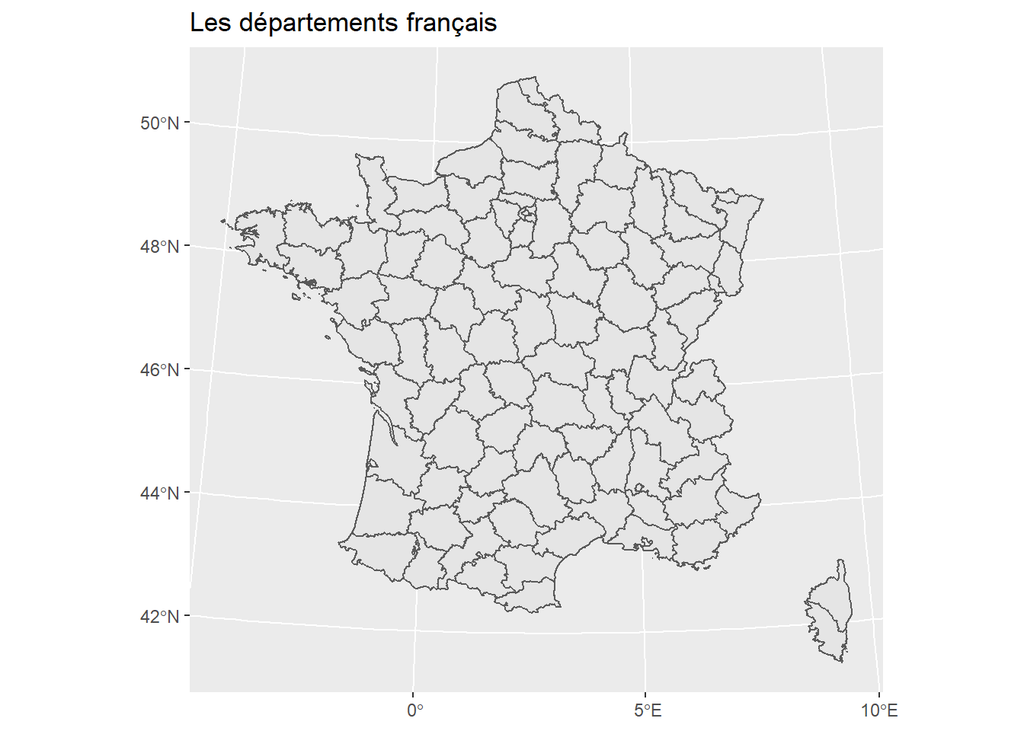

```r
  ggplot(data = dep_fr) +
    geom_sf() +
    ggtitle("Les départements français")
```

# Analyses

## Question A - Visualiser les différences des taux de variation selon les départements

### Faire un tableau pour comparer les taux de variation des communes entre les départements

cf.Tableau 5c de la Fiche Insee

```r
    pop_dep <- pop_comm %>%
        group_by(DEP) %>%
        summarise(P17_POP = sum (P17_POP),
                  P07_POP = sum (P07_POP),)

    pop_dep$txvar <- ((pop_dep$P17_POP / pop_dep$P07_POP)^0.1 - 1)*100

    pop_dep$txvar <- round (pop_dep$txvar, digits = 2)
    print (pop_dep)
```

```
## # A tibble: 100 × 4
##    DEP   P17_POP P07_POP txvar
##    <chr>   <dbl>   <dbl> <dbl>
##  1 01     643350  574553  1.14
##  2 02     534490  537884 -0.06
##  3 03     337988  342992 -0.15
##  4 04     163915  156017  0.5
##  5 05     141284  132517  0.64
##  6 06    1083310 1084314 -0.01
##  7 07     325712  309349  0.52
##  8 08     273579  284517 -0.39
##  9 09     153153  148496  0.31
## 10 10     310020  300607  0.31
## # … with 90 more rows
```

### Faire une carte pour comparer les taux de variation des communes entre les départements

cf.Carte 5c de la Fiche Insee

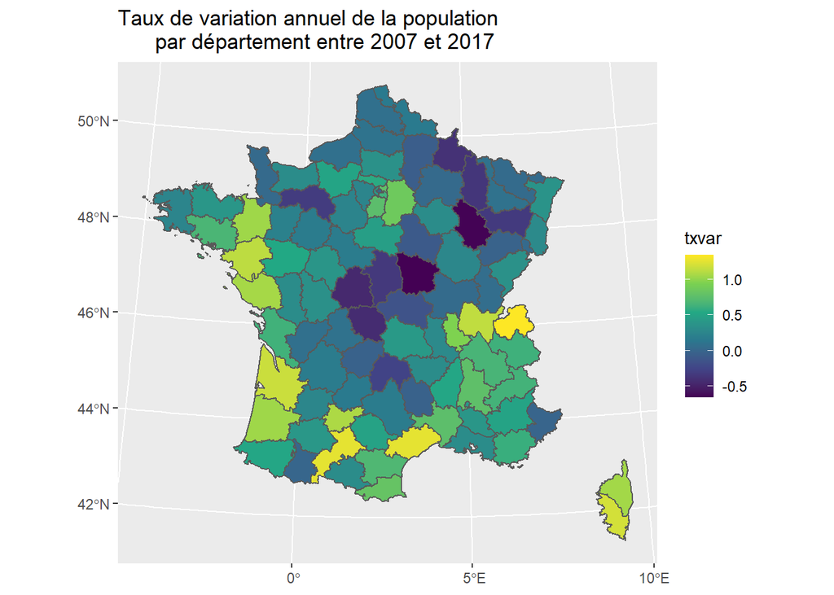

```r
    dep_fr$DEP <- dep_fr$INSEE_DEP
    dep_fr <- dep_fr %>%
      left_join(pop_dep, by = "DEP")

    ggplot(data = dep_fr) +
      geom_sf(aes(fill = txvar)) +
      scale_fill_viridis_c(option = "viridis")+
      ggtitle("Taux de variation annuel de la population
      par département entre 2007 et 2017")
```

Refaire la carte avec les 5 mêmes classes que dans la fiche Insee (< -0,1 ; [-0,1 ; 0,1[ ; [0,1 ; 0,5[ ; [0,5 ; 1[ ; >=1)

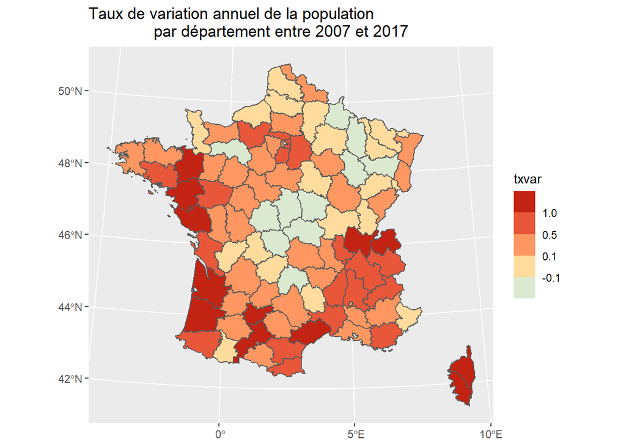

```r
    ggplot(data = dep_fr) +
      geom_sf(aes(fill = txvar)) +
      ggtitle("Taux de variation annuel de la population
              par département entre 2007 et 2017") +
      scale_fill_stepsn(
                  colors = c("#a6cee3", "#ffffc0", "#fc8d59", "#e34a33", "#b30000"),
                  breaks = c(-0.1, 0.1, 0.5, 1.0, 2.0))
```

### Faire un modèle multiniveau (vide) pour comparer les taux de variation des communes entre les départements

Modèle nul/vide (ie. sans variables explicatives) - modèle avec intercept aléatoire avec la commune en niveau 1 et le département en niveau 2

```r
    mod_0<-lmer (txvar ~ 1 + (1 | DEP),data=pop_comm, REML = FALSE)
    summary(mod_0)
```

```
## Linear mixed model fit by maximum likelihood . t-tests use Satterthwaite's
##   method [lmerModLmerTest]
## Formula: txvar ~ 1 + (1 | DEP)
##    Data: pop_comm
##
##      AIC      BIC   logLik deviance df.resid
## 117296.2 117321.6 -58645.1 117290.2    34944
##
## Scaled residuals:
##     Min      1Q  Median      3Q     Max
## -7.0043 -0.5952 -0.0571  0.5386  8.9071
##
## Random effects:
##  Groups   Name        Variance Std.Dev.
##  DEP      (Intercept) 0.1961   0.4428
##  Residual             1.6624   1.2893
## Number of obs: 34947, groups:  DEP, 100
##
## Fixed effects:
##             Estimate Std. Error       df t value Pr(>|t|)
## (Intercept)  0.50338    0.04539 90.54453   11.09   <2e-16 ***
## ---
## Signif. codes:  0 '***' 0.001 '**' 0.01 '*' 0.05 '.' 0.1 ' ' 1
```

Stocker les infos du modèle vide dans un tableau

```r
# Modéle Nul
summary_stat <- data.frame()
summary_stat["mod_0","N"] <- dim(mod_0@frame)[1]
summary_stat["mod_0", "AIC" ] <-summary(mod_0)$AIC[1][[1]]
summary_stat["mod_0", "BIC" ] <- summary(mod_0)$AIC[2][[1]]
summary_stat["mod_0", "vrn1" ] <- as.data.frame(summary(mod_0)$varcor)[2,]$vcov
summary_stat["mod_0", "vrn2" ] <- summary(mod_0)$varcor[1][[1]][[1]]

summary_stat["mod_0", "Total_Var" ] <- summary_stat$vrn2[1] + summary_stat$vrn1[1]
summary_stat["mod_0", "ICC" ] <- summary_stat$vrn2[1] / summary_stat$Total_Var[1]
summary_stat["mod_0", "InterClass" ] <- summary_stat$vrn1[1] / summary_stat$Total_Var[1]

summary_stat
```

|  | N | AIC | BIC | vrn1 | vrn2 | Total_Var | ICC | InterClass |
| --- | --- | --- | --- | --- | --- | --- | --- | --- |
| mod_0 | 34947 | 117296.2 | 117321.6 | 1.662367 | 0.1960938 | 1.858461 | 0.1055141 | 0.8944859 |

=> On peut en conclure que 10% de la variance du modèle vide concerne le niveau 2 (département)

Explorer les résultats du Modèle vide : Cartographier les **résidus** de niveau 2 (par département)

Extraction des résidus de niveau 2

```r
    mod_0_residDep<-ranef(mod_0)
    mod_0_residDep <- as.data.frame(mod_0_residDep$DEP)
```

Création d’une colonne pour l’identifiant département et renommer la variable

```r
    mod_0_residDep$DEP <-row.names(mod_0_residDep)

    mod_0_residDep <- mod_0_residDep %>%
      rename(residDep_mod_0 = '(Intercept)')
```

Jointure entre le tableau de résidus et la couche des départements

```r
    dep_fr <- dep_fr %>%
      left_join(mod_0_residDep, by = "DEP")
```

Cartographie des résidus au niveau des départements pour le modèle vide

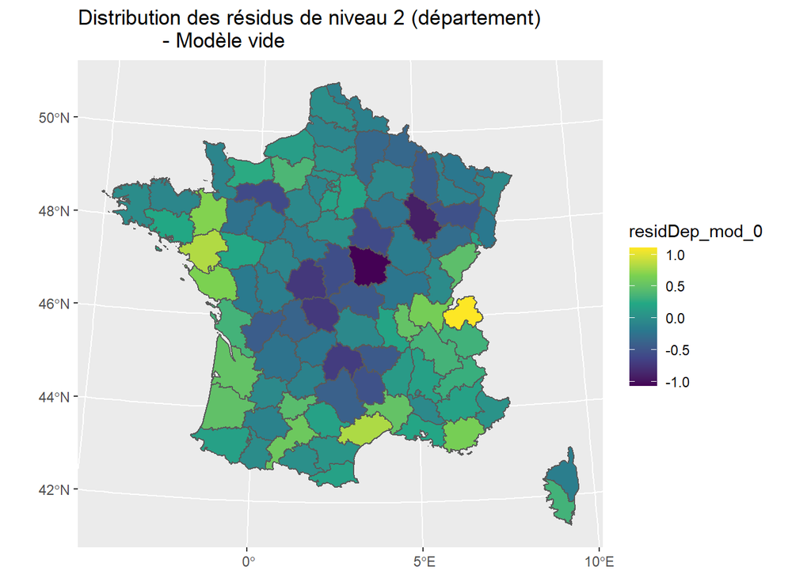

```r
     ggplot(data = dep_fr) +
      geom_sf(aes(fill = residDep_mod_0))  +
      scale_fill_viridis_c(option = "viridis")+
      ggtitle("Distribution des résidus de niveau 2 (département)
              - Modèle vide")
```

=> Pusiqu’il s’agit d’une carte des residus de niveau 2 (departement) pour le modèle vide, cela signifie que : - les departements avec des résidus élévés sont ceux où le taux de variation est élévé - les départements avec des résidus faibles sont ceux où le taux de variation est faible Carte très similaire à celle des taux de variations par départements (différence de centrage-réduction).

## Question B - Est-ce que le taux de variation des communes est associé à leur densité ?

### Faire un tableau pour comparer les taux de variation des communes selon le niveau de densité des communes

cf Figure 2

```r
    pop_grilleDensite <- pop_comm %>%
      group_by(densite) %>%
      summarise(P17_POP = sum (P17_POP),
                P07_POP = sum (P07_POP))

    pop_grilleDensite$txvar <- ((pop_grilleDensite$P17_POP / pop_grilleDensite$P07_POP)^0.1 - 1)*100

    pop_grilleDensite$txvar <- round (pop_grilleDensite$txvar, digits = 2 )

    print(pop_grilleDensite)
```

```
## # A tibble: 4 × 4
##   densite  P17_POP  P07_POP txvar
##   <fct>      <dbl>    <dbl> <dbl>
## 1 1       25161322 24282010  0.36
## 2 2       19539972 18744040  0.42
## 3 3       19435033 18224723  0.65
## 4 4        2388012  2353179  0.15
```

### Faire un modèle multiniveau pour mesurer la relation avec le niveau de densité des communes

Modèle 1full, avec la variable “densité en 4 categories” comme variable explicative au niveau des communes (effet fixe)

```r
    mod_1full<-lmer (txvar ~ 1 + densite + (1 | DEP),data=pop_comm, REML = FALSE)
    summary(mod_1full)
```

```
## Linear mixed model fit by maximum likelihood . t-tests use Satterthwaite's
##   method [lmerModLmerTest]
## Formula: txvar ~ 1 + densite + (1 | DEP)
##    Data: pop_comm
##
##      AIC      BIC   logLik deviance df.resid
## 116786.4 116837.1 -58387.2 116774.4    34941
##
## Scaled residuals:
##     Min      1Q  Median      3Q     Max
## -7.1360 -0.6045 -0.0772  0.5319  9.1064
##
## Random effects:
##  Groups   Name        Variance Std.Dev.
##  DEP      (Intercept) 0.1639   0.4048
##  Residual             1.6387   1.2801
## Number of obs: 34947, groups:  DEP, 100
##
## Fixed effects:
##               Estimate Std. Error         df t value Pr(>|t|)
## (Intercept)  4.196e-01  6.435e-02  4.672e+02   6.520 1.83e-10 ***
## densite2     1.588e-01  5.479e-02  2.831e+04   2.899  0.00375 **
## densite3     2.190e-01  5.190e-02  2.559e+04   4.219 2.46e-05 ***
## densite4    -1.467e-01  5.313e-02  2.539e+04  -2.762  0.00576 **
## ---
## Signif. codes:  0 '***' 0.001 '**' 0.01 '*' 0.05 '.' 0.1 ' ' 1
##
## Correlation of Fixed Effects:
##          (Intr) denst2 denst3
## densite2 -0.702
## densite3 -0.756  0.895
## densite4 -0.747  0.877  0.953
```

=> Le taux de variation des communes est associé à leur niveau de densité de façon statistiquement significative. Comparées aux communes de densité 1 (denses) : les communes de densité 2 (intermédiaires) ont un taux de variation plus élevé (+ 0.158%), les communes de densité 3 (peu denses) ont un taux de variation encore plus élevé (+ 0.219%) et les communes de densité 4 (tres peu denses) ont un taux de variation plus faible (- 0.146%).

## Question C - Si on classe les communes en deux catégroies selon leur densité, quelle classification est la plus pertinente à intégrer au modèle multiniveau ?

### Si on fait comme dans la fiche Insee ?

1: communes densément peuplées & de densité intermédiaire 2: communes peu denses & très peu denses

```r
  pop_comm$densite_duo <- ifelse (pop_comm$densite %in% 1:2 , 1,
                                  ifelse (pop_comm$densite %in% 3:4 , 2,
                                          NA))

  pop_comm$densite_duo <- as.factor (pop_comm$densite_duo)
```

Modèle 1_duo, avec la variable “densité” (selon les 2 categories Insee) comme variable explicative au niveau des communes (effet fixe)

```r
    mod_1_duo<-lmer (txvar ~ 1 + densite_duo + (1 | DEP),data=pop_comm, REML = FALSE)
    summary(mod_1_duo)
```

```
## Linear mixed model fit by maximum likelihood . t-tests use Satterthwaite's
##   method [lmerModLmerTest]
## Formula: txvar ~ 1 + densite_duo + (1 | DEP)
##    Data: pop_comm
##
##      AIC      BIC   logLik deviance df.resid
## 117297.7 117331.6 -58644.9 117289.7    34943
##
## Scaled residuals:
##     Min      1Q  Median      3Q     Max
## -7.0026 -0.5938 -0.0560  0.5384  8.9077
##
## Random effects:
##  Groups   Name        Variance Std.Dev.
##  DEP      (Intercept) 0.1954   0.442
##  Residual             1.6624   1.289
## Number of obs: 34947, groups:  DEP, 100
##
## Fixed effects:
##                Estimate Std. Error         df t value Pr(>|t|)
## (Intercept)   5.173e-01  4.923e-02  1.262e+02  10.508   <2e-16 ***
## densite_duo2 -1.654e-02  2.291e-02  3.434e+04  -0.722     0.47
## ---
## Signif. codes:  0 '***' 0.001 '**' 0.01 '*' 0.05 '.' 0.1 ' ' 1
##
## Correlation of Fixed Effects:
##             (Intr)
## densite_du2 -0.391
```

### Si on isole les communes peu denses ?

0: communes densément peuplées & de densité intermédiaire & très peu denses 1: communes peu denses)

```r
  pop_comm$peudenses <- ifelse (pop_comm$densite %in% 3 , 1,
                                          0)
  pop_comm$peudenses <- as.factor (pop_comm$peudenses)
```

Modèle 1, avec la variable “peudenses : Oui/Non” comme variable explicative au niveau des communes (effet fixe)

```r
    mod_1<-lmer (txvar ~ 1 + peudenses + (1 | DEP),data=pop_comm, REML = FALSE)
    summary(mod_1)
```

```
## Linear mixed model fit by maximum likelihood . t-tests use Satterthwaite's
##   method [lmerModLmerTest]
## Formula: txvar ~ 1 + peudenses + (1 | DEP)
##    Data: pop_comm
##
##      AIC      BIC   logLik deviance df.resid
## 116911.8 116945.7 -58451.9 116903.8    34943
##
## Scaled residuals:
##     Min      1Q  Median      3Q     Max
## -7.1298 -0.5951 -0.0708  0.5294  9.0509
##
## Random effects:
##  Groups   Name        Variance Std.Dev.
##  DEP      (Intercept) 0.1784   0.4224
##  Residual             1.6445   1.2824
## Number of obs: 34947, groups:  DEP, 100
##
## Fixed effects:
##              Estimate Std. Error        df t value Pr(>|t|)
## (Intercept) 3.563e-01  4.401e-02 9.454e+01   8.096 1.95e-12 ***
## peudenses1  2.843e-01  1.442e-02 3.494e+04  19.720  < 2e-16 ***
## ---
## Signif. codes:  0 '***' 0.001 '**' 0.01 '*' 0.05 '.' 0.1 ' ' 1
##
## Correlation of Fixed Effects:
##            (Intr)
## peudenses1 -0.169
```

=> Si on regroupe les communes en deux catégories (denses & intermédiaires d’un côté; et peu denses et très peu denses de l’autre), le taux de variation des communes n’apparait plus associé au niveau de densité de façon statistiquement significative.

=> Si on isole les communes peu denses (celles pour lesquelles les taux de variation était le plus fort), le taux de variation des communes apparait associé au niveau de densité de façon statistiquement significative. Comparées aux autres communes, les communes peu denses ont un taux plus élevé de variation annuelle de leur population (+ 0.284%)

Cartographie par département des coefficients liés à la densité (effet fixe) pour le modèle 1

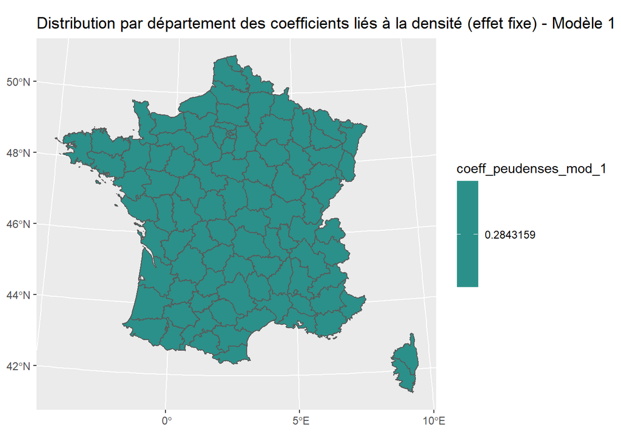

```r
    mod_1_coef <- coef(mod_1)
    mod_1_coef <- as.data.frame (mod_1_coef$DEP)
    mod_1_coef$DEP <-row.names(mod_1_coef)
    mod_1_coef <- mod_1_coef %>%
      rename(coeff_intercept_mod_1 = '(Intercept)',
             coeff_peudenses_mod_1 = peudenses1)

    dep_fr <- dep_fr %>%
      left_join(mod_1_coef, by = "DEP")

    ggplot(data = dep_fr) +
      geom_sf(aes(fill = coeff_peudenses_mod_1))  +
      scale_fill_viridis_c(option = "viridis") +
      ggtitle("Distribution par département des coefficients liés à la densité (effet fixe) - Modèle 1")
```

=> La cartographie des coefficients liés à la densité (par départament) révèle que tous les départements sont “logés à la meme enseigne” avec une valeur de 0.28 ce qui est logique car le modèle spécifie un **effet fixe** pour la densité. Le coefficent de 0.28 correspond bien à l’Estimate des Fixed effects donné par le modèle.

Cartographie des résidus au niveau des départements pour le modèle 1

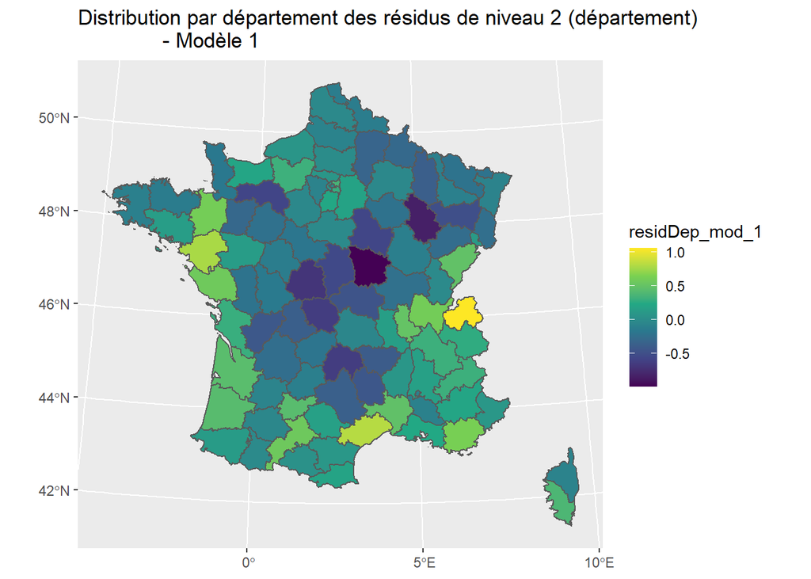

```r
    mod_1_residDep<-ranef(mod_1)
    mod_1_residDep <- as.data.frame (mod_1_residDep$DEP)

    mod_1_residDep$DEP <-row.names(mod_1_residDep)

    mod_1_residDep <- mod_1_residDep %>%
      rename(residDep_mod_1 = '(Intercept)')

    dep_fr <- dep_fr %>%
      left_join(mod_1_residDep, by = "DEP")

    ggplot(data = dep_fr) +
      geom_sf(aes(fill = residDep_mod_1))  +
      scale_fill_viridis_c(option = "viridis") +
      ggtitle("Distribution par département des résidus de niveau 2 (département)
              - Modèle 1")
```

=> La carte révèle que certains départements ont un taux de variation supérieur (résidu positif - en jaune) ou inférieur (résidu négatif - bleu foncé) à celui modélisé par le modèle 1. Peut-être que les départements avec des résidus positifs sont ceux où il y a des grandes villes? Hypothèses à tester!

## Question D - Est-ce que le taux de variation des communes est aussi associé à la présence d’une grande ville dans le département ?

Créer variable au niveau du département : présence/absence d’une commune > 150 000 hb. et la rapatrier au niveau de la table communes

```r
    maxpop_dep <- pop_comm %>%
      group_by(DEP) %>%
      summarise(max_P17_POP = max (P17_POP))
    maxpop_dep$gdcommuneInDep <- ifelse (maxpop_dep$max_P17_POP > 150000, 1, 0)
    maxpop_dep$gdcommuneInDep <- as.factor (maxpop_dep$gdcommuneInDep)

    pop_comm <- pop_comm %>%
      left_join(maxpop_dep, by = "DEP")

    table (pop_comm$gdcommuneInDep)
```

```
##
##     0     1
## 27695  7252
```

Cartographier les départements avec des grandes communes et comparer la carte avec la carte précédente (Carte des résidus de niveau 2 - Modèle 1 )

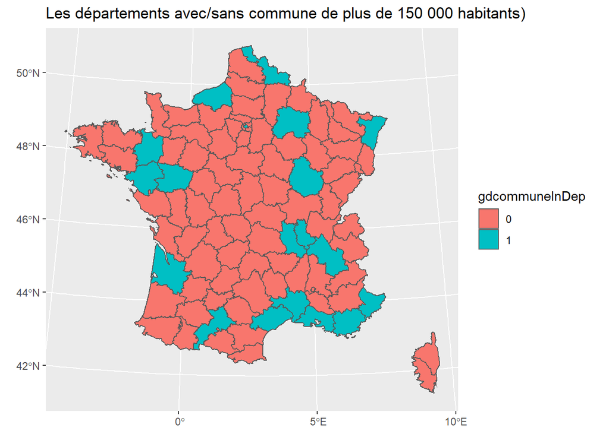

```r
    dep_fr <- dep_fr %>%
      left_join(maxpop_dep, by = "DEP")

    ggplot(data = dep_fr) +
      geom_sf(aes(fill = gdcommuneInDep))  +
      ggtitle("Les départements avec/sans commune de plus de 150 000 habitants)")
```

Modèle 2, avec la variable “densité” comme variable explicative au niveau des communes et une autre variable “présence d’une grande commune” au niveau des départements (effets fixes)

```r
    mod_2<-lmer (txvar ~ 1 + peudenses + gdcommuneInDep + (1 | DEP),data=pop_comm, REML = FALSE)
    summary(mod_2)
```

```
## Linear mixed model fit by maximum likelihood . t-tests use Satterthwaite's
##   method [lmerModLmerTest]
## Formula: txvar ~ 1 + peudenses + gdcommuneInDep + (1 | DEP)
##    Data: pop_comm
##
##      AIC      BIC   logLik deviance df.resid
## 116901.5 116943.8 -58445.7 116891.5    34942
##
## Scaled residuals:
##     Min      1Q  Median      3Q     Max
## -7.1286 -0.5972 -0.0690  0.5292  9.0524
##
## Random effects:
##  Groups   Name        Variance Std.Dev.
##  DEP      (Intercept) 0.1531   0.3913
##  Residual             1.6446   1.2824
## Number of obs: 34947, groups:  DEP, 100
##
## Fixed effects:
##                  Estimate Std. Error        df t value Pr(>|t|)
## (Intercept)     2.856e-01  4.524e-02 9.141e+01   6.314 9.66e-09 ***
## peudenses1      2.841e-01  1.442e-02 3.493e+04  19.707  < 2e-16 ***
## gdcommuneInDep1 3.787e-01  1.037e-01 8.538e+01   3.650  0.00045 ***
## ---
## Signif. codes:  0 '***' 0.001 '**' 0.01 '*' 0.05 '.' 0.1 ' ' 1
##
## Correlation of Fixed Effects:
##             (Intr) pdnss1
## peudenses1  -0.160
## gdcmmnInDp1 -0.423 -0.013
```

=> Le taux de variation des communes est associé à la présence de “grande commune” (> 150 000 habitants) dans le département. Comparées aux communes situées dans un département sans “grande commune”, les communes situées dans un département avec une “grande commune” ont un taux de variation plus élevé (+ 0.378%).

Cartographie des résidus au niveau des départements pour le modèle 2

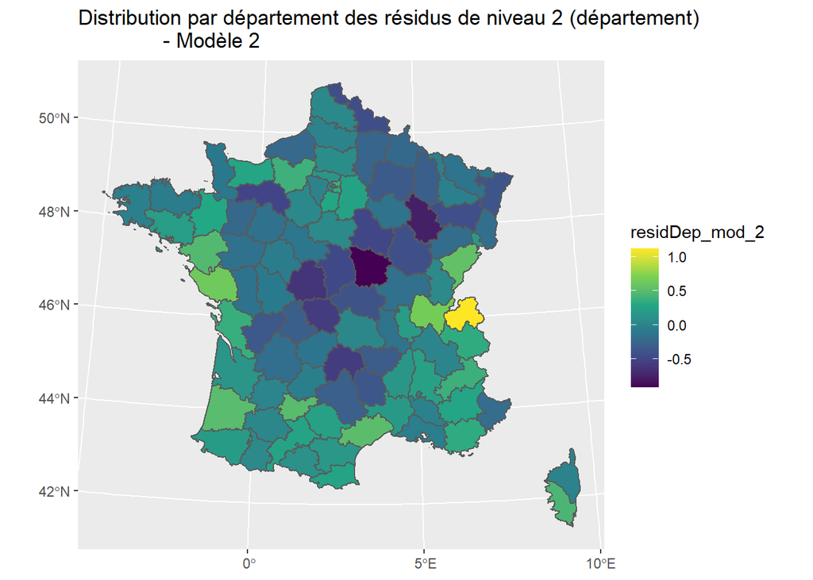

```r
    mod_2_residDep<-ranef(mod_2)
    mod_2_residDep <- as.data.frame (mod_2_residDep$DEP)

    mod_2_residDep$DEP <-row.names(mod_2_residDep)

    mod_2_residDep <- mod_2_residDep %>%
      rename(residDep_mod_2 = '(Intercept)')

    dep_fr <- dep_fr %>%
      left_join(mod_2_residDep, by = "DEP")

    ggplot(data = dep_fr) +
      geom_sf(aes(fill = residDep_mod_2))  +
      scale_fill_viridis_c(option = "viridis") +
      ggtitle("Distribution par département des résidus de niveau 2 (département)
              - Modèle 2")
```

=> On n’observe pas de grands changements entre cette carte des résidus de niveau 2 pour le modèle 2 et la carte des résidus de niveau 2 pour le modèle 1 : ce sont les mêmes départements qui présentent des résidus positifs et des résidus négatifs. D’autres variables explicatives mériteraient d’être encore explorées…

## Question E - Est-ce que la différence inter-departementale dans les taux de variation s’explique par la composition des communes des départements en termes de densité (effets de composition) ? et par la présence d’une grande ville dans le département (effet de contexte) ?

Comparaison de la variance intra et inter departement entre les modèles 0, 1 et 2

```r
# Modèle Nul
summary_stat <- data.frame()
summary_stat["mod_0","N"] <- dim(mod_0@frame)[1]
summary_stat["mod_0", "AIC" ] <-summary(mod_0)$AIC[1][[1]]
summary_stat["mod_0", "BIC" ] <- summary(mod_0)$AIC[2][[1]]
summary_stat["mod_0", "vrn1" ] <- as.data.frame(summary(mod_0)$varcor)[2,]$vcov
summary_stat["mod_0", "vrn2" ] <- summary(mod_0)$varcor[1][[1]][[1]]

summary_stat["mod_0", "Total_Var" ] <- summary_stat$vrn2[1] + summary_stat$vrn1[1]
summary_stat["mod_0", "ICC" ] <- summary_stat$vrn2[1] / summary_stat$Total_Var[1]
summary_stat["mod_0", "InterClass" ] <- summary_stat$vrn1[1] / summary_stat$Total_Var[1]

# Modèle 1
summary_stat["mod_1","N"] <- dim(mod_1@frame)[1]
summary_stat["mod_1", "AIC" ] <-summary(mod_1)$AIC[1][[1]]
summary_stat["mod_1", "BIC" ] <- summary(mod_1)$AIC[2][[1]]
summary_stat["mod_1", "vrn1" ] <- as.data.frame(summary(mod_1)$varcor)[2,]$vcov
summary_stat["mod_1", "vrn2" ] <- summary(mod_1)$varcor[1][[1]][[1]]

summary_stat["mod_1", "Total_Var" ] <- summary_stat$vrn2[2] + summary_stat$vrn1[2]
summary_stat["mod_1", "ICC" ] <- summary_stat$vrn2[2] / summary_stat$Total_Var[2]
summary_stat["mod_1", "InterClass" ] <- summary_stat$vrn1[2] / summary_stat$Total_Var[2]


# Modèle 2
summary_stat["mod_2","N"] <- dim(mod_2@frame)[1]
summary_stat["mod_2", "AIC" ] <-summary(mod_2)$AIC[1][[1]]
summary_stat["mod_2", "BIC" ] <- summary(mod_2)$AIC[2][[1]]
summary_stat["mod_2", "vrn1" ] <- as.data.frame(summary(mod_2)$varcor)[2,]$vcov
summary_stat["mod_2", "vrn2" ] <- summary(mod_2)$varcor[1][[1]][[1]]

summary_stat["mod_2", "Total_Var" ] <- summary_stat$vrn2[3] + summary_stat$vrn1[3]
summary_stat["mod_2", "ICC" ] <- summary_stat$vrn2[3] / summary_stat$Total_Var[3]
summary_stat["mod_2", "InterClass" ] <- summary_stat$vrn1[3] / summary_stat$Total_Var[3]
summary_stat
```

|  | N | AIC | BIC | vrn1 | vrn2 | Total_Var | ICC | InterClass |
| --- | --- | --- | --- | --- | --- | --- | --- | --- |
| mod_0 | 34947 | 117296.2 | 117321.6 | 1.662367 | 0.1960938 | 1.858461 | 0.10551407 | 0.8944859 |
| mod_1 | 34947 | 116911.8 | 116945.7 | 1.644460 | 0.1784312 | 1.822892 | 0.09788362 | 0.9021164 |
| mod_2 | 34947 | 116901.5 | 116943.8 | 1.644562 | 0.1530942 | 1.797656 | 0.08516326 | 0.9148367 |

=> Les **variances** de niveau 1 et de niveau 2 diminuent entre les différents modèles. La part de la variance attribuable au niveau 2 passe de 10,5% dans le modèle vide à 8,5% dans le modèle 2. Les **différences départementales** des taux de variation peuvent s’expliquer par un **effet de composition** (les départements ont plus ou moins de communes peu denses) et un **effet de contexte** (des départements avec ou sans grande commune).

## Question F - L’effet de la densité des communes varie-t-il selon les départements?

Modèle 3, avec la variable “peudenses : Oui/Non” comme variable explicative au niveau des communes **(effet aléaloire)**

```r
    mod_3<-lmer (txvar ~ 1 + peudenses + gdcommuneInDep + (1 + peudenses | DEP),data=pop_comm, REML = FALSE)
    summary(mod_3)
```

```
## Linear mixed model fit by maximum likelihood . t-tests use Satterthwaite's
##   method [lmerModLmerTest]
## Formula: txvar ~ 1 + peudenses + gdcommuneInDep + (1 + peudenses | DEP)
##    Data: pop_comm
##
##      AIC      BIC   logLik deviance df.resid
## 116758.0 116817.2 -58372.0 116744.0    34940
##
## Scaled residuals:
##     Min      1Q  Median      3Q     Max
## -7.1034 -0.5932 -0.0741  0.5273  9.0626
##
## Random effects:
##  Groups   Name        Variance Std.Dev. Corr
##  DEP      (Intercept) 0.16406  0.4050
##           peudenses1  0.06719  0.2592   -0.24
##  Residual             1.63132  1.2772
## Number of obs: 34947, groups:  DEP, 100
##
## Fixed effects:
##                 Estimate Std. Error       df t value Pr(>|t|)
## (Intercept)      0.26717    0.04668 90.30053   5.723 1.35e-07 ***
## peudenses1       0.30453    0.03107 80.18891   9.800 2.32e-15 ***
## gdcommuneInDep1  0.40640    0.10447 86.12288   3.890 0.000197 ***
## ---
## Signif. codes:  0 '***' 0.001 '**' 0.01 '*' 0.05 '.' 0.1 ' ' 1
##
## Correlation of Fixed Effects:
##             (Intr) pdnss1
## peudenses1  -0.269
## gdcmmnInDp1 -0.412 -0.009
```

```r
    confint(mod_3, oldNames=FALSE)
```

```
## Computing profile confidence intervals ...
```

```
##                                     2.5 %     97.5 %
## sd_(Intercept)|DEP              0.3465297 0.47790090
## cor_peudenses1.(Intercept)|DEP -0.4719061 0.01426824
## sd_peudenses1|DEP               0.2106525 0.31893380
## sigma                           1.2677898 1.28678765
## (Intercept)                     0.1750044 0.36061636
## peudenses1                      0.2430447 0.36646429
## gdcommuneInDep1                 0.1969820 0.61552233
```

=> L’effet fixe associé au fait d’être une commune peu dense est toujours positif (et statistiquement significatif). Idem pour le fait d’être dans un département avec une “grande”commune”.

=> L’écart type de l’effet aléaltoire de la densité est de 0.2592 avec un intervalle de confiance entre 0.21 et 0.318 (cf. sd_peudenses1|DEP). Il est alors intéressant de faire une carte pour savoir comment varie l’effet de la densité selon les départements.

Cartographie par département des coefficients liés à la densité (effet aléatoire) pour le modèle 3

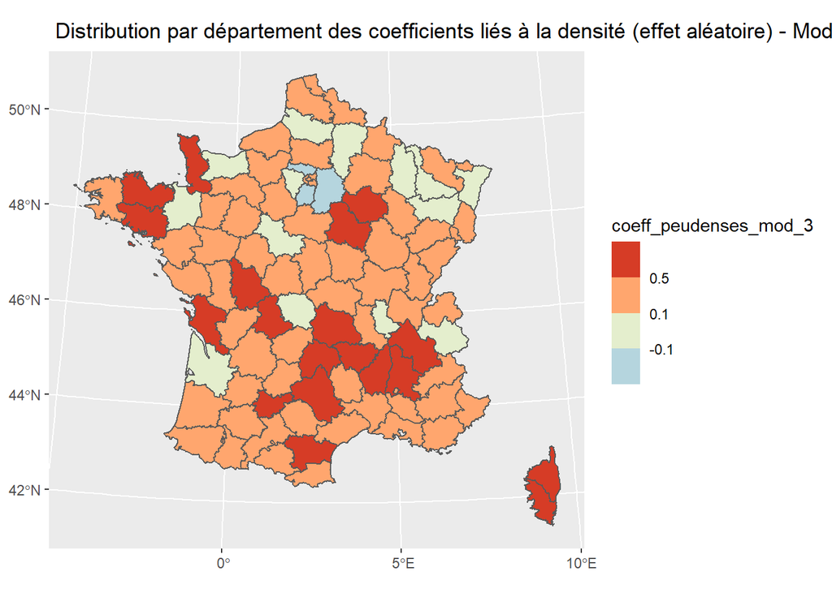

```r
    mod_3_coef <- coef(mod_3)
    mod_3_coef <- as.data.frame (mod_3_coef$DEP)
    mod_3_coef$DEP <-row.names(mod_3_coef)
    mod_3_coef <- mod_3_coef %>%
      rename(coeff_intercept_mod_3 = '(Intercept)',
             coeff_peudenses_mod_3 = peudenses1)

    dep_fr <- dep_fr %>%
      left_join(mod_3_coef, by = "DEP")

    ggplot(data = dep_fr) +
      geom_sf(aes(fill = coeff_peudenses_mod_3))  +
      scale_fill_viridis_c(option = "viridis") +
      ggtitle(" Distribution par département des coefficients liés à la densité (effet aléatoire) - Modèle 3") +
      scale_fill_stepsn(
                  colors = c("#a6cee3", "#ffffc0", "#fc8d59", "#e34a33", "#b30000"),
                  breaks = c(-0.5, -0.1, 0.1, 0.5))
```

=> L’effet associé au fait d’être une commune peu dense varie selon les départements. Dans les departements de la grande couronne d’Ile-de-France (en bleu clair sur la carte), cet effet est par exemple négatif. A l’inverse cet effet est positif (et assez fort) dans certains départements situés en Corse, en Bretagne ou dans le Massif-central etc. (en rouge sur la carte)

Comparaison de la variance intra et inter departement entre les modèles 0, 1, 2 et 3

```r
# Modéle 3
summary_stat["mod_3","N"] <- dim(mod_3@frame)[1]
summary_stat["mod_3", "AIC" ] <-summary(mod_3)$AIC[1][[1]]
summary_stat["mod_3", "BIC" ] <- summary(mod_3)$AIC[2][[1]]
summary_stat["mod_3", "vrn1" ] <- as.data.frame(summary(mod_3)$varcor)[2,]$vcov
summary_stat["mod_3", "vrn2" ] <- summary(mod_3)$varcor[1][[1]][[1]]

summary_stat["mod_3", "Total_Var" ] <- summary_stat$vrn2[4] + summary_stat$vrn1[4]
summary_stat["mod_3", "ICC" ] <- summary_stat$vrn2[4] / summary_stat$Total_Var[4]
summary_stat["mod_3", "InterClass" ] <- summary_stat$vrn1[4] / summary_stat$Total_Var[4]

summary_stat
```

|  | N | AIC | BIC | vrn1 | vrn2 | Total_Var | ICC | InterClass |
| --- | --- | --- | --- | --- | --- | --- | --- | --- |
| mod_0 | 34947 | 117296.2 | 117321.6 | 1.66236723 | 0.1960938 | 1.8584610 | 0.10551407 | 0.8944859 |
| mod_1 | 34947 | 116911.8 | 116945.7 | 1.64446037 | 0.1784312 | 1.8228916 | 0.09788362 | 0.9021164 |
| mod_2 | 34947 | 116901.5 | 116943.8 | 1.64456188 | 0.1530942 | 1.7976561 | 0.08516326 | 0.9148367 |
| mod_3 | 34947 | 116758.0 | 116817.2 | 0.06718565 | 0.1640650 | 0.2312506 | 0.70946822 | 0.2905318 |

Cartographie des résidus au niveau des départements pour le modèle 3

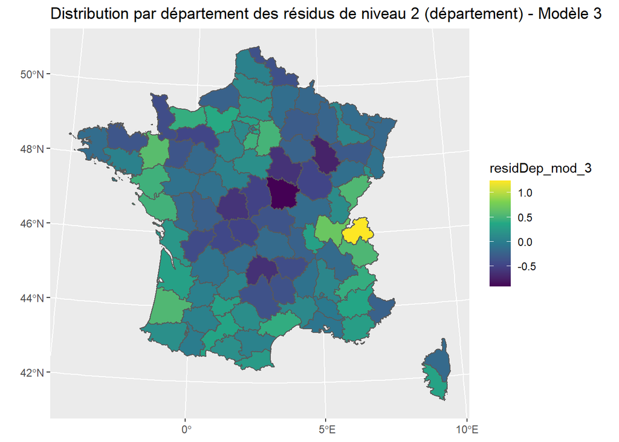

```r
    mod_3_residDep<-ranef(mod_3)
    mod_3_residDep <- as.data.frame (mod_3_residDep$DEP)

    mod_3_residDep$DEP <-row.names(mod_3_residDep)

    mod_3_residDep <- mod_3_residDep %>%
      rename(residDep_mod_3 = '(Intercept)')

    dep_fr <- dep_fr %>%
      left_join(mod_3_residDep, by = "DEP")

    ggplot(data = dep_fr) +
      geom_sf(aes(fill = residDep_mod_3))  +
      scale_fill_viridis_c(option = "viridis") +
      ggtitle("Distribution par département des résidus de niveau 2 (département) - Modèle 3")
```